# Projet MSPL

DIALLO Thierno, MESOUAK Salaheddin et RAZAFINDRABE Timoty

2023-03-19

# Introduction

## Context

Dans cette étude, nous nous appuyons sur deux bases de données toutes deux issues et récupérable sur le site de l’[OCDE](https://stats.oecd.org/?lang=fr#).

> **Remarque :** Le dataset complèt présente d’autres variables et méthodes de mesure sur une périeode de temps plus large. Nous avons utilisé l’interface du site pour filtrée la base et ne récpérer que les données dont nous avons besoin.

### Le niveaux de PIB par tête et de productivité

Cette base de données est extraite du Compendium de l’OCDE sur les Indicateurs de Productivité et présente le Produit Intérieur Brut annuel (en millions, USD, prix constants, PPA de 2015) pour une selection de 48 pays entre 2000 et 2020.

```r
datasetPIB = read.csv("data/PIB_2000_2020.csv", sep=",", quote="\"")
#View(datasetPIB)
```

### Les émissions de gaz à effet de serre

Cet ensemble de données est issu de la Soumission des inventaires nationaux 2022 à la Convention Cadre des Nations Unies sur les Changements Climatiques (CCNUCC, tableaux CRF), et des réponses au questionnaire sur l’état de l’environnement de l’OCDE.

Il présente les tendances des émissions anthropiques des gaz à effet de serre (émissions totales excluant l’UTCF, en milliers de tonne d’équivalent CO<sub>2</sub>) pour une selection de 58 pays entre 2000 et 2020.

```r
datasetGES = read.csv("data/GES_2000_2020.csv", sep=",", quote="\"")
#View(datasetGES)
```

## Description de la problématique

Le but de cette étude est de déterminer s’il éxiste un lien entre le PIB et l’émission de Gaz à Effet de Serre.

# Méthodologie

## Nettoyage des données

```r
datasetPIB %>%
  select(Pays, Temps, Value) %>%
  na.omit() %>%
  head()
```

|  | Pays | Temps | Value |
| --- | --- | --- | --- |
| 1 | Australie | 2000 | 722383.2 |
| 2 | Australie | 2001 | 751232.2 |
| 3 | Australie | 2002 | 774606.0 |
| 4 | Australie | 2003 | 807268.3 |
| 5 | Australie | 2004 | 832727.6 |
| 6 | Australie | 2005 | 855549.6 |

```r
datasetGES %>%
  select(Pays, Année, Value) %>%
  na.omit() %>%
  head()
```

|  | Pays | Année | Value |
| --- | --- | --- | --- |
| 1 | Australie | 2000 | 489528.6 |
| 2 | Australie | 2001 | 497352.0 |
| 3 | Australie | 2002 | 501000.8 |
| 4 | Australie | 2003 | 501129.0 |
| 5 | Australie | 2004 | 518408.4 |
| 6 | Australie | 2005 | 524811.8 |

## Choix de présentation des données

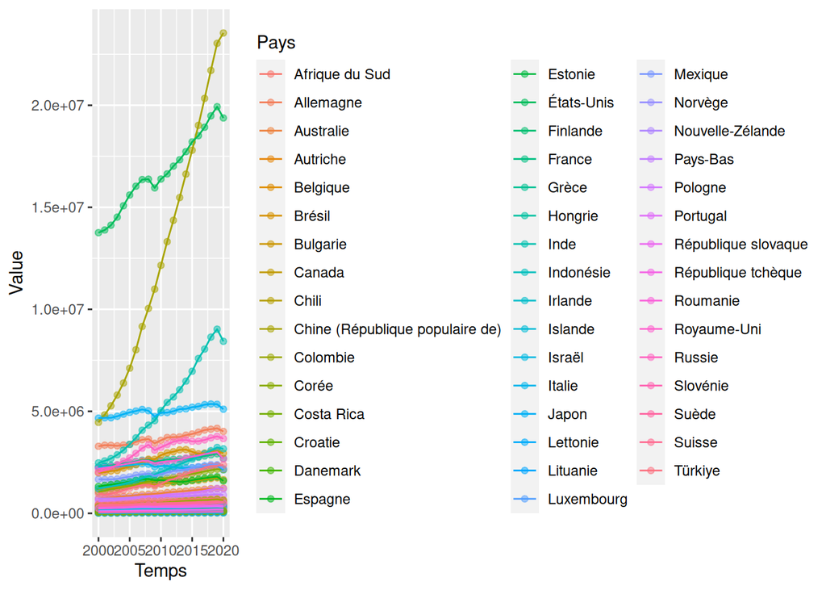

```r
ggplot(datasetPIB, aes(x=Temps, y=Value, color=Pays)) +
  geom_point(alpha=0.5) +
  geom_line()
```

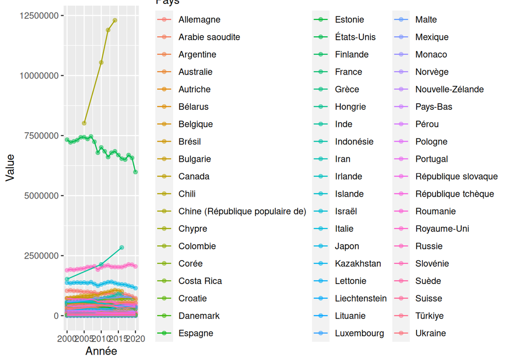

```r
ggplot(datasetGES, aes(x=Année, y=Value, color=Pays)) +
  geom_point(alpha=0.5) +
  geom_line()
```

# Analyse par Programmation Littérale